# Assessing the maxrange to SD ratio

Bainbridge et al.’s data

Ian Hussey

04 May 2026

# Dependencies

```r
library(tidyverse)
library(scales)
library(knitr)
library(kableExtra)
library(betareg)
library(ggrepel)

source("beta_smd_bounds.R")
```

# Get data

```r
dat_bainbridge <- read_csv("../../../data/bainbridge et al/processed/data_processed_itemlevel_long.csv") |>
  mutate(min_response = 1,
         max_response = 5) |>
  mutate(scale = case_when(
    scale == "BFI_personality" & subscale == "o" ~ "openness",
    scale == "BFI_personality" & subscale == "c" ~ "conscientiousness",
    scale == "BFI_personality" & subscale == "e" ~ "extraversion",
    scale == "BFI_personality" & subscale == "a" ~ "agreeableness",
    scale == "BFI_personality" & subscale == "n" ~ "neuroticism",
    TRUE ~ scale  # Keeps the original value if conditions aren't met
  ))


dat_poopchoc <- read_csv("../../../data/not-so-simple-preferences/data_processed_after_exclusions.csv")  |>
  mutate(min_response = 1,
         max_response = 7) |> # not so simple preferences study (not bainbridge)
  select(id = participant_id,
         min_response,
         max_response,
         poop = classic_poop,
         chocolate = classic_chocolate,
         pedophile, love, murder, vacation, racist,
         honest, dishonest,
         girls_skirts, boys_skirts, cats_legs, fish_legs,
         attention_check1_numeric,
         attention_check2_numeric) |>
  pivot_longer(cols = c(-id, -min_response, -max_response),
               names_to = "scale",
               values_to = "response") |>
  mutate(subscale = scale)

dat <- bind_rows(dat_bainbridge,
                 dat_poopchoc)

#dat <- dat_bainbridge
```

# n participants in datasets

```r
data_s1 <- read_csv("../../../data/bainbridge et al/raw/s1.csv")
data_s2 <- read_csv("../../../data/bainbridge et al/raw/s2.csv")
data_s3 <- read_csv("../../../data/bainbridge et al/raw/s3.csv")

bind_cols(
  data_s1 |> count(name = "n_study1"),
  data_s2 |> count(name = "n_study2"),
  data_s3 |> count(name = "n_study3")
) |>
  kable() |>
  kable_classic(full_width = FALSE)
```

| n_study1 | n_study2 | n_study3 |
| --- | --- | --- |
| 253 | 398 | 388 |

# n scales

including multi-item self report scales and single item (or small number of items) attitude scales.

```r
dat |>
  distinct(scale) |>
  count(name = "n_scales") |>
  kable() |>
  kable_classic(full_width = FALSE)
```

| n_scales |
| --- |
| 65 |

# Range to SD ratio

CIs on M:

$$m \pm t_{1-\alpha/2, n-1} \left( \frac{s}{\sqrt{n}} \right)$$

CIs on SD:

$$\left[ \frac{(n-1)s^2}{\chi^2_{\alpha/2, n-1}},
\frac{(n-1)s^2}{\chi^2_{1-\alpha/2, n-1}} \right]$$

```r
# Function to calculate SD CI bounds
# Returns a tibble to allow for easy unnesting if desired,
# or can be split into two functions.
calc_sd_ci <- function(x, conf_level = 0.95, side = "lower") {
  n <- sum(!is.na(x))
  df <- n - 1
  sd_val <- sd(x, na.rm = TRUE)

  alpha <- 1 - conf_level

  if (side == "lower") {
    # Chi-square upper critical value for the lower bound
    chi_val <- qchisq(1 - alpha/2, df)
    return(sqrt((df * sd_val^2) / chi_val))
  } else {
    # Chi-square lower critical value for the upper bound
    chi_val <- qchisq(alpha/2, df)
    return(sqrt((df * sd_val^2) / chi_val))
  }
}

dat_nitems <- dat |>
  count(id, scale, subscale) |>
  group_by(scale, subscale) |>
  summarize(n_items = median(n))

calc_pomp <- function(x, min_possible_response, max_possible_response, n_items) {
  ((x - (min_possible_response*n_items)) / ((max_possible_response*n_items) - (min_possible_response*n_items)))
}

# Smithson-Verkuilen transformation
# to offset values from the [0, 1] limits that Beta regression can't handle
# often used in Beta regression
calc_sk_transf <- function(y, n){
  (y * (n - 1) + 0.5) / n
}


dat_sumscores <- dat |>
  group_by(id, scale, subscale, min_response, max_response) |>
  summarize(sumscore = sum(response, na.rm = TRUE),
            .groups = "drop") |>
  left_join(dat_nitems, by = c("scale", "subscale")) |>
  mutate(pomp_sumscore = calc_pomp(sumscore,
                                   min_possible_response = min_response,
                                   max_possible_response = max_response,
                                   n_items = n_items)) |>
  group_by(scale, subscale) |>
  mutate(n = n()) |>
  ungroup() |>
  mutate(pomp_sumscore_sk_transf = calc_sk_transf(pomp_sumscore, n))

# ggplot(dat_sumscores, aes(pomp_sumscore, pomp_sumscore_sk_transf)) +
#   geom_point()

res <- dat_sumscores |>
  group_by(scale, subscale, n_items, min_response, max_response) |>
  summarize(n = n(),
            m = mean(sumscore),
            sd = sd(sumscore),
            # --- Mean CIs (using t-distribution) ---
            # Standard Error: sd / sqrt(n)
            se = sd / sqrt(n),
            # t-critical value for 95% CI
            t_crit = qt(0.975, df = n - 1),
            m_lower = m - (t_crit * se),
            m_upper = m + (t_crit * se),
            sd_lower = calc_sd_ci(sumscore, side = "lower"),
            sd_upper = calc_sd_ci(sumscore, side = "upper"),
            .groups = "drop") |>
  mutate(min_possible = min_response * n_items, # min possible response for all scales is 1
         max_possible = max_response * n_items, # max possible response for all scales is 1
         max_range = max_possible - min_possible,
         pomp_m = m/max_range,
         romp_m = max_range/m,
         pomp_sd = sd/max_range,
         romp_sd = max_range/sd) |>
  select(-min_possible, -max_possible, -se, -t_crit) |>
  relocate(sd, .before = sd_lower)

# table
res |>
  mutate_if(is.numeric, roundwork::round_up, digits = 2) |>
  kable() |>
  kable_classic(full_width = FALSE)
```

| scale | subscale | n_items | min_response | max_response | n | m | m_lower | m_upper | sd | sd_lower | sd_upper | max_range | pomp_m | romp_m | pomp_sd | romp_sd |
| --- | --- | --- | --- | --- | --- | --- | --- | --- | --- | --- | --- | --- | --- | --- | --- | --- |
| Aggression | a | 3 | 1 | 5 | 1027 | 7.49 | 7.32 | 7.65 | 2.66 | 2.55 | 2.78 | 12 | 0.62 | 1.60 | 0.22 | 4.50 |
| Aggression | h | 3 | 1 | 5 | 1027 | 8.95 | 8.79 | 9.11 | 2.60 | 2.49 | 2.71 | 12 | 0.75 | 1.34 | 0.22 | 4.62 |
| Aggression | p | 3 | 1 | 5 | 1027 | 6.92 | 6.75 | 7.10 | 2.91 | 2.79 | 3.04 | 12 | 0.58 | 1.73 | 0.24 | 4.13 |
| Aggression | v | 3 | 1 | 5 | 1027 | 7.86 | 7.70 | 8.03 | 2.72 | 2.60 | 2.84 | 12 | 0.66 | 1.53 | 0.23 | 4.42 |
| Ambiguity Tolerance | ambig | 13 | 1 | 5 | 246 | 40.27 | 39.42 | 41.13 | 6.83 | 6.27 | 7.49 | 52 | 0.77 | 1.29 | 0.13 | 7.62 |
| BAS | d | 4 | 1 | 5 | 781 | 12.91 | 12.69 | 13.13 | 3.14 | 3.00 | 3.31 | 16 | 0.81 | 1.24 | 0.20 | 5.09 |
| BAS | fs | 4 | 1 | 5 | 781 | 13.03 | 12.80 | 13.25 | 3.18 | 3.03 | 3.35 | 16 | 0.81 | 1.23 | 0.20 | 5.03 |
| BAS | r | 5 | 1 | 5 | 781 | 20.13 | 19.92 | 20.33 | 2.96 | 2.82 | 3.12 | 20 | 1.01 | 0.99 | 0.15 | 6.75 |
| BIS | bis | 7 | 1 | 5 | 781 | 24.98 | 24.56 | 25.40 | 5.95 | 5.67 | 6.26 | 28 | 0.89 | 1.12 | 0.21 | 4.71 |
| Curiosity | e | 4 | 1 | 5 | 246 | 14.57 | 14.26 | 14.87 | 2.42 | 2.22 | 2.65 | 16 | 0.91 | 1.10 | 0.15 | 6.62 |
| Curiosity | f | 3 | 1 | 5 | 246 | 9.91 | 9.63 | 10.18 | 2.17 | 1.99 | 2.38 | 12 | 0.83 | 1.21 | 0.18 | 5.53 |
| Desirability of Control | d | 4 | 1 | 5 | 246 | 15.33 | 15.09 | 15.58 | 1.97 | 1.81 | 2.16 | 16 | 0.96 | 1.04 | 0.12 | 8.12 |
| Desirability of Control | da | 4 | 1 | 5 | 246 | 11.87 | 11.53 | 12.21 | 2.73 | 2.51 | 3.00 | 16 | 0.74 | 1.35 | 0.17 | 5.86 |
| Desirability of Control | l | 7 | 1 | 5 | 246 | 22.69 | 22.16 | 23.22 | 4.22 | 3.87 | 4.63 | 28 | 0.81 | 1.23 | 0.15 | 6.64 |
| Dogmatism | dogma | 20 | 1 | 5 | 246 | 47.02 | 45.87 | 48.18 | 9.21 | 8.46 | 10.10 | 80 | 0.59 | 1.70 | 0.12 | 8.69 |
| Emotion Regulation: Reappraisal | erreap | 6 | 1 | 5 | 781 | 21.04 | 20.71 | 21.37 | 4.73 | 4.50 | 4.97 | 24 | 0.88 | 1.14 | 0.20 | 5.08 |
| Emotion Regulation: Suppression | ersup | 4 | 1 | 5 | 781 | 11.61 | 11.38 | 11.85 | 3.36 | 3.20 | 3.54 | 16 | 0.73 | 1.38 | 0.21 | 4.76 |
| Empathy | empa | 16 | 1 | 5 | 246 | 62.78 | 61.73 | 63.82 | 8.34 | 7.66 | 9.15 | 64 | 0.98 | 1.02 | 0.13 | 7.67 |
| Empathy: Empathic Concern | empec | 4 | 1 | 5 | 781 | 15.67 | 15.45 | 15.88 | 3.06 | 2.92 | 3.22 | 16 | 0.98 | 1.02 | 0.19 | 5.23 |
| Empathy: Fantasy | empf | 4 | 1 | 5 | 781 | 14.71 | 14.46 | 14.95 | 3.48 | 3.32 | 3.66 | 16 | 0.92 | 1.09 | 0.22 | 4.59 |
| Empathy: Personal Distress | emppd | 4 | 1 | 5 | 781 | 10.99 | 10.74 | 11.23 | 3.51 | 3.34 | 3.69 | 16 | 0.69 | 1.46 | 0.22 | 4.56 |
| Empathy: Perspective-Taking | emppt | 4 | 1 | 5 | 781 | 14.92 | 14.71 | 15.14 | 3.08 | 2.93 | 3.24 | 16 | 0.93 | 1.07 | 0.19 | 5.20 |
| Flourishing | flour | 8 | 1 | 5 | 246 | 29.84 | 29.31 | 30.37 | 4.21 | 3.87 | 4.62 | 32 | 0.93 | 1.07 | 0.13 | 7.59 |
| Gratitude | gratit | 6 | 1 | 5 | 246 | 23.54 | 23.09 | 24.00 | 3.66 | 3.36 | 4.01 | 24 | 0.98 | 1.02 | 0.15 | 6.56 |
| Grit | c | 6 | 1 | 5 | 1027 | 17.09 | 16.81 | 17.38 | 4.62 | 4.43 | 4.83 | 24 | 0.71 | 1.40 | 0.19 | 5.19 |
| Grit | p | 6 | 1 | 5 | 1027 | 21.07 | 20.81 | 21.32 | 4.13 | 3.96 | 4.32 | 24 | 0.88 | 1.14 | 0.17 | 5.81 |
| Hope | a | 4 | 1 | 5 | 1027 | 13.75 | 13.56 | 13.93 | 3.08 | 2.96 | 3.22 | 16 | 0.86 | 1.16 | 0.19 | 5.19 |
| Hope | p | 4 | 1 | 5 | 1027 | 14.36 | 14.20 | 14.53 | 2.73 | 2.61 | 2.85 | 16 | 0.90 | 1.11 | 0.17 | 5.87 |
| IPIP_personality | a | 24 | 1 | 5 | 1027 | 88.44 | 87.70 | 89.19 | 12.14 | 11.64 | 12.69 | 96 | 0.92 | 1.09 | 0.13 | 7.91 |
| IPIP_personality | c | 24 | 1 | 5 | 1027 | 85.19 | 84.32 | 86.06 | 14.21 | 13.62 | 14.85 | 96 | 0.89 | 1.13 | 0.15 | 6.76 |

[output cut: 62 more lines]

```r
temp <- res |>
  mutate_if(is.numeric, roundwork::round_up, digits = 4) |>
  select(scale, subscale, pomp_sd)
```

# POMP distributions

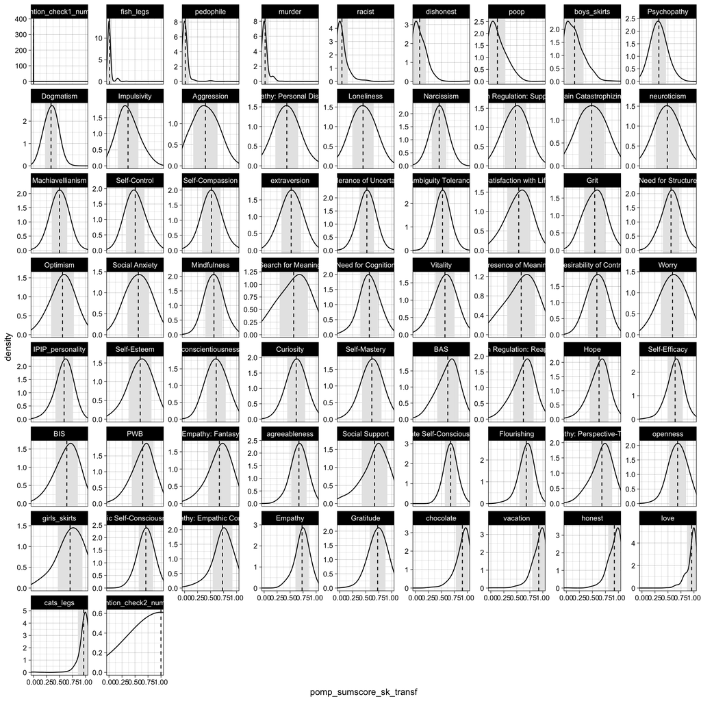

```r
pomp_dist <- dat_sumscores |>
  group_by(scale) |>
  mutate(mean_pomp_sumscore = mean(pomp_sumscore_sk_transf),
         sd_pomp_sumscore = sd(pomp_sumscore_sk_transf)) |>
  ungroup()

pomp_dist |>
  mutate(scale = fct_reorder(scale, mean_pomp_sumscore)) |>
  ggplot(aes(pomp_sumscore_sk_transf)) +
  geom_rect(aes(xmin = mean_pomp_sumscore - sd_pomp_sumscore,
                xmax = mean_pomp_sumscore + sd_pomp_sumscore,
                ymin = -Inf, ymax = Inf),
            fill = "grey90", alpha = 0.5) +
  geom_vline(aes(xintercept = mean_pomp_sumscore), linetype = 'dashed') +
  geom_density(adjust = 2.5) +
  coord_cartesian(xlim = c(0, 1)) +
  theme_linedraw() +
  facet_wrap(~ scale, scales = "free_y")
```

```r
pomp_dist |>
  group_by(scale) |>
  summarize(mean_pomp_sumscore = mean(pomp_sumscore_sk_transf),
            sd_pomp_sumscore = sd(pomp_sumscore_sk_transf)) |>
  mutate_if(is.numeric, round, digits = 3) |>
  arrange(mean_pomp_sumscore) |>
  kable() |>
  kable_classic(full_width = FALSE)
```

| scale | mean_pomp_sumscore | sd_pomp_sumscore |
| --- | --- | --- |
| attention_check1_numeric | 0.001 | 0.000 |
| fish_legs | 0.011 | 0.042 |
| pedophile | 0.014 | 0.072 |
| murder | 0.018 | 0.070 |
| racist | 0.043 | 0.112 |
| dishonest | 0.085 | 0.122 |
| poop | 0.127 | 0.150 |
| boys_skirts | 0.158 | 0.171 |
| Psychopathy | 0.325 | 0.136 |
| Dogmatism | 0.338 | 0.115 |
| Impulsivity | 0.366 | 0.198 |
| Aggression | 0.401 | 0.235 |
| Empathy: Personal Distress | 0.437 | 0.219 |
| Loneliness | 0.449 | 0.206 |
| Narcissism | 0.460 | 0.140 |
| Emotion Regulation: Suppression | 0.476 | 0.210 |
| Pain Catastrophizing | 0.487 | 0.249 |
| neuroticism | 0.487 | 0.222 |
| Machiavellianism | 0.500 | 0.149 |
| Self-Control | 0.504 | 0.179 |
| Self-Compassion | 0.516 | 0.178 |
| extraversion | 0.521 | 0.191 |
| Intolerance of Uncertainty | 0.523 | 0.139 |
| Ambiguity Tolerance | 0.524 | 0.131 |
| Satisfaction with Life | 0.537 | 0.224 |
| Grit | 0.545 | 0.200 |
| Need for Structure | 0.559 | 0.162 |
| Optimism | 0.560 | 0.220 |
| Social Anxiety | 0.563 | 0.210 |
| Mindfulness | 0.565 | 0.165 |
| Search for Meaning | 0.569 | 0.272 |
| Need for Cognition | 0.570 | 0.177 |
| Vitality | 0.571 | 0.186 |
| Presence of Meaning | 0.585 | 0.268 |
| Desirability of Control | 0.587 | 0.174 |
| Worry | 0.588 | 0.226 |
| IPIP_personality | 0.590 | 0.169 |
| Self-Esteem | 0.600 | 0.214 |
| conscientiousness | 0.609 | 0.185 |
| Curiosity | 0.617 | 0.171 |
| Self-Mastery | 0.618 | 0.189 |
| BAS | 0.626 | 0.204 |
| Emotion Regulation: Reappraisal | 0.627 | 0.197 |
| Hope | 0.628 | 0.183 |
| Self-Efficacy | 0.638 | 0.146 |
| BIS | 0.642 | 0.212 |
| PWB | 0.647 | 0.209 |
| Empathy: Fantasy | 0.669 | 0.217 |
| agreeableness | 0.670 | 0.151 |
| Social Support | 0.671 | 0.246 |
| Private Self-Consciousness | 0.680 | 0.111 |
| Empathy: Perspective-Taking | 0.682 | 0.192 |
| Flourishing | 0.682 | 0.131 |
| openness | 0.686 | 0.164 |
| girls_skirts | 0.704 | 0.237 |
| Public Self-Consciousness | 0.708 | 0.136 |
| Empathy: Empathic Concern | 0.729 | 0.191 |
| Empathy | 0.730 | 0.130 |
| Gratitude | 0.730 | 0.152 |
| chocolate | 0.906 | 0.128 |
| vacation | 0.921 | 0.128 |
| honest | 0.922 | 0.119 |
| love | 0.955 | 0.090 |
| cats_legs | 0.967 | 0.109 |
| attention_check2_numeric | 0.999 | 0.000 |

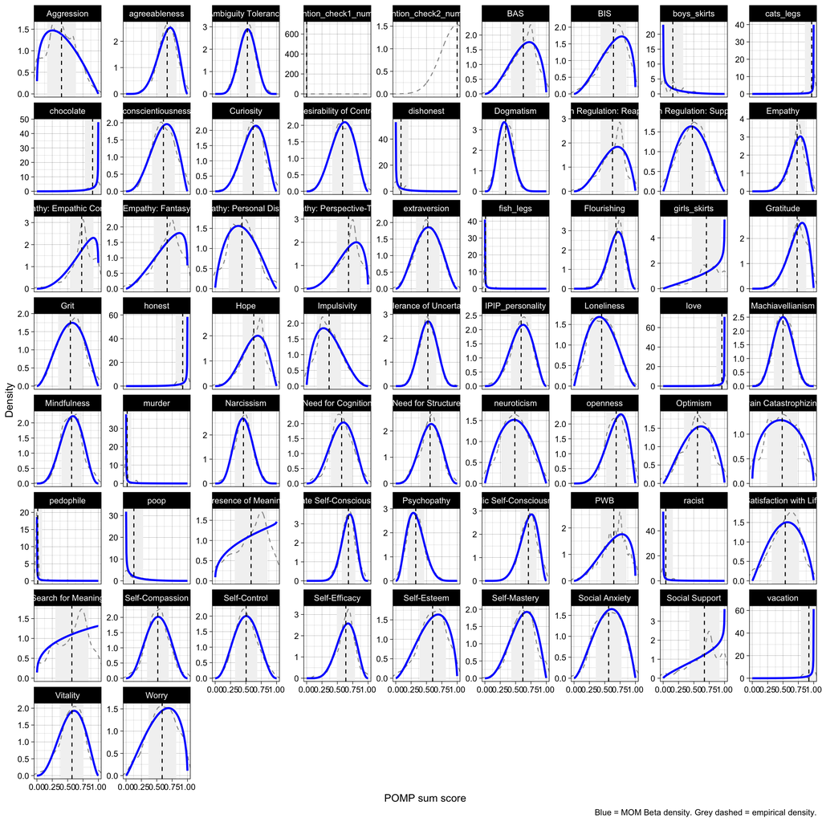

```r
# MOM Beta parameters per scale, using the bounds-library function.
# pomp_sumscore_sk_transf is already SK-transformed into (0, 1), so no
# additional offset is needed here. Scales with zero variance (e.g. attention
# checks where everyone gave the same answer) get NA shapes and are dropped
# from downstream Beta plots and bound calculations.
safe_beta_fit_mom <- function(M, SD) {
  if (!is.finite(SD) || SD <= 0 || !is.finite(M) || M <= 0 || M >= 1) {
    return(list(mu = M, sigma_tilde = SD, phi = NA_real_,
                alpha = NA_real_, beta = NA_real_,
                bd_ceiling = NA_real_, impossible = TRUE))
  }
  beta_fit_mom(M, SD, scale_min = 0, scale_max = 1)
}

beta_params <- dat_sumscores |>
  group_by(scale) |>
  summarise(
    m_pomp  = mean(pomp_sumscore_sk_transf, na.rm = TRUE),
    sd_pomp = sd(pomp_sumscore_sk_transf,   na.rm = TRUE),
    .groups = "drop"
  ) |>
  rowwise() |>
  mutate(
    fit = list(safe_beta_fit_mom(m_pomp, sd_pomp)),
    shape1 = fit$alpha,
    shape2 = fit$beta
  ) |>
  ungroup() |>
  select(scale, m_pomp, sd_pomp, shape1, shape2)

# High-res grid for the MOM density curves
grid <- expand_grid(
  scale = unique(dat_sumscores$scale),
  x_val = seq(0.001, 0.999, length.out = 200)
) |>
  left_join(beta_params, by = "scale") |>
  mutate(y_val = dbeta(x_val, shape1, shape2))

# Plot
dat_sumscores |>
  group_by(scale) |>
  mutate(mean_pomp = mean(pomp_sumscore_sk_transf, na.rm = TRUE),
         sd_pomp = sd(pomp_sumscore_sk_transf, na.rm = TRUE)) |>
  ggplot(aes(x = pomp_sumscore_sk_transf)) +
  # Shaded SD region
  geom_rect(aes(xmin = mean_pomp - sd_pomp, xmax = mean_pomp + sd_pomp,
                ymin = -Inf, ymax = Inf), fill = "grey95") +
  # Dashed empirical density for comparison
  geom_density(aes(y = after_stat(density)), adjust = 1, color = "grey60", linetype = "dashed") +
  # MOM Beta density
  geom_line(data = grid, aes(x = x_val, y = y_val), color = "blue", size = 1) +
  geom_vline(aes(xintercept = mean_pomp), linetype = "dashed") +
  theme_linedraw() +
  coord_cartesian(xlim = c(0, 1)) +
  facet_wrap(~ scale, scales = "free_y") +
  labs(x = "POMP sum score", y = "Density",
       caption = "Blue = MOM Beta density. Grey dashed = empirical density.")
```

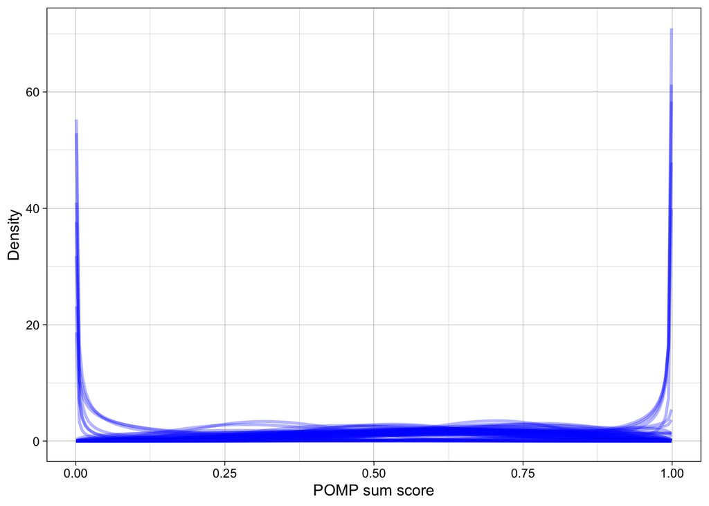

```r
dat_sumscores |>
  group_by(scale) |>
  mutate(mean_pomp = mean(pomp_sumscore_sk_transf, na.rm = TRUE),
         sd_pomp = sd(pomp_sumscore_sk_transf, na.rm = TRUE)) |>
  ggplot(aes(x = pomp_sumscore_sk_transf, color = scale, group = scale)) +
  # MOM Beta densities, one per scale
  geom_line(data = grid, aes(x = x_val, y = y_val), color = "blue", alpha = 0.3, size = 1) +
  theme_linedraw() +
  labs(x = "POMP sum score", y = "Density")
```

# Validating MOM Beta against MLE Beta regression

In production the bound method only has summary statistics (M, SD) to work from, so the Beta fit must be done by method of moments. To check that this is a defensible stand-in for a proper-likelihood fit, here we also fit a constant-precision Beta regression (intercept-only mean, constant phi) by maximum likelihood on the participant-level data and compare the recovered (mu, phi) against the MOM estimates.

## Per-scale (mu, phi) from MOM and MLE

```r
fit_one_mle <- function(d) {
  tryCatch(
    betareg::betareg(pomp_sumscore_sk_transf ~ 1, data = d),
    error = function(e) NULL
  )
}

mle_fits_list <- split(dat_sumscores, dat_sumscores$scale) |>
  lapply(fit_one_mle)
```

```
## Error in chol.default(K) : the leading minor of order 2 is not positive
```

```r
mle_params <- tibble(
  scale = names(mle_fits_list),
  mu_mle  = vapply(mle_fits_list, function(f) {
    if (is.null(f)) NA_real_ else unname(plogis(coef(f)[["(Intercept)"]]))
  }, numeric(1)),
  phi_mle = vapply(mle_fits_list, function(f) {
    if (is.null(f)) NA_real_ else unname(f$coefficients$precision)
  }, numeric(1))
)

mom_vs_mle <- beta_params |>
  mutate(mu_mom = m_pomp,
         phi_mom = shape1 + shape2) |>
  select(scale, mu_mom, phi_mom) |>
  left_join(mle_params, by = "scale") |>
  mutate(mu_diff   = mu_mle  - mu_mom,
         phi_ratio = phi_mle / phi_mom)

mom_vs_mle |>
  arrange(desc(abs(log(phi_ratio)))) |>
  mutate_if(is.numeric, round, digits = 3) |>
  kable(caption = "Per-scale MOM vs MLE Beta fits, sorted by |log(phi_ratio)|.") |>
  kable_classic(full_width = FALSE)
```

Per-scale MOM vs MLE Beta fits, sorted by |log(phi_ratio)|.

| scale | mu_mom | phi_mom | mu_mle | phi_mle | mu_diff | phi_ratio |
| --- | --- | --- | --- | --- | --- | --- |
| pedophile | 0.014 | 1.568 | 0.018 | 1.496400e+01 | 0.004 | 9.543 |
| fish_legs | 0.011 | 5.056 | 0.011 | 2.799900e+01 | 0.001 | 5.538 |
| murder | 0.018 | 2.712 | 0.030 | 8.006000e+00 | 0.011 | 2.952 |
| cats_legs | 0.967 | 1.700 | 0.938 | 3.335000e+00 | -0.029 | 1.962 |
| Social Support | 0.671 | 2.637 | 0.660 | 1.514000e+00 | -0.011 | 0.574 |
| Empathy: Empathic Concern | 0.729 | 4.414 | 0.732 | 2.588000e+00 | 0.003 | 0.586 |
| Empathy: Personal Distress | 0.437 | 4.127 | 0.429 | 2.436000e+00 | -0.007 | 0.590 |
| girls_skirts | 0.704 | 2.716 | 0.717 | 1.633000e+00 | 0.013 | 0.601 |
| Aggression | 0.401 | 3.353 | 0.375 | 2.035000e+00 | -0.025 | 0.607 |
| Empathy: Fantasy | 0.669 | 3.685 | 0.668 | 2.287000e+00 | -0.001 | 0.620 |
| boys_skirts | 0.158 | 3.558 | 0.150 | 2.223000e+00 | -0.008 | 0.625 |
| Optimism | 0.560 | 4.092 | 0.554 | 2.583000e+00 | -0.006 | 0.631 |
| PWB | 0.647 | 4.224 | 0.652 | 2.708000e+00 | 0.005 | 0.641 |
| Pain Catastrophizing | 0.487 | 3.031 | 0.477 | 1.945000e+00 | -0.010 | 0.642 |
| racist | 0.043 | 2.276 | 0.062 | 3.542000e+00 | 0.019 | 1.556 |
| Search for Meaning | 0.569 | 2.322 | 0.546 | 1.523000e+00 | -0.022 | 0.656 |
| Self-Mastery | 0.618 | 5.644 | 0.632 | 3.710000e+00 | 0.014 | 0.657 |
| Satisfaction with Life | 0.537 | 3.972 | 0.516 | 2.624000e+00 | -0.021 | 0.661 |
| Hope | 0.628 | 5.993 | 0.628 | 3.972000e+00 | -0.001 | 0.663 |
| Empathy: Perspective-Taking | 0.682 | 4.881 | 0.686 | 3.270000e+00 | 0.004 | 0.670 |
| dishonest | 0.085 | 4.213 | 0.095 | 2.859000e+00 | 0.010 | 0.679 |
| poop | 0.127 | 3.919 | 0.125 | 2.670000e+00 | -0.002 | 0.681 |
| openness | 0.686 | 6.955 | 0.693 | 4.873000e+00 | 0.007 | 0.701 |
| Presence of Meaning | 0.585 | 2.387 | 0.565 | 1.699000e+00 | -0.019 | 0.712 |
| Impulsivity | 0.366 | 4.945 | 0.354 | 3.541000e+00 | -0.011 | 0.716 |
| Emotion Regulation: Reappraisal | 0.627 | 5.048 | 0.625 | 3.617000e+00 | -0.002 | 0.717 |
| Emotion Regulation: Suppression | 0.476 | 4.662 | 0.468 | 3.362000e+00 | -0.008 | 0.721 |
| Self-Compassion | 0.516 | 6.873 | 0.523 | 4.990000e+00 | 0.006 | 0.726 |
| BAS | 0.626 | 4.605 | 0.629 | 3.384000e+00 | 0.003 | 0.735 |
| Self-Esteem | 0.600 | 4.229 | 0.598 | 3.127000e+00 | -0.002 | 0.739 |
| love | 0.955 | 4.270 | 0.955 | 5.681000e+00 | -0.001 | 1.330 |
| neuroticism | 0.487 | 4.079 | 0.482 | 3.093000e+00 | -0.006 | 0.758 |
| Curiosity | 0.617 | 7.076 | 0.625 | 5.436000e+00 | 0.008 | 0.768 |
| BIS | 0.642 | 4.105 | 0.641 | 3.183000e+00 | -0.001 | 0.775 |
| Grit | 0.545 | 5.179 | 0.553 | 4.017000e+00 | 0.008 | 0.776 |
| Vitality | 0.571 | 6.058 | 0.570 | 4.735000e+00 | -0.001 | 0.782 |
| Social Anxiety | 0.563 | 4.579 | 0.566 | 3.581000e+00 | 0.003 | 0.782 |
| Loneliness | 0.449 | 4.820 | 0.436 | 3.796000e+00 | -0.013 | 0.787 |
| Self-Efficacy | 0.638 | 9.775 | 0.641 | 7.735000e+00 | 0.003 | 0.791 |
| conscientiousness | 0.609 | 5.979 | 0.616 | 4.742000e+00 | 0.008 | 0.793 |
| honest | 0.922 | 4.077 | 0.917 | 3.246000e+00 | -0.005 | 0.796 |
| agreeableness | 0.670 | 8.683 | 0.673 | 6.952000e+00 | 0.004 | 0.801 |
| Gratitude | 0.730 | 7.550 | 0.734 | 6.131000e+00 | 0.004 | 0.812 |
| Mindfulness | 0.565 | 8.028 | 0.569 | 6.557000e+00 | 0.004 | 0.817 |
| Need for Cognition | 0.570 | 6.797 | 0.571 | 5.631000e+00 | 0.001 | 0.829 |
| Public Self-Consciousness | 0.708 | 10.146 | 0.711 | 8.447000e+00 | 0.003 | 0.833 |
| extraversion | 0.521 | 5.873 | 0.521 | 4.911000e+00 | 0.000 | 0.836 |
| chocolate | 0.906 | 4.195 | 0.909 | 3.548000e+00 | 0.002 | 0.846 |
| Worry | 0.588 | 3.725 | 0.593 | 3.204000e+00 | 0.005 | 0.860 |
| vacation | 0.921 | 3.409 | 0.915 | 3.066000e+00 | -0.006 | 0.899 |
| Self-Control | 0.504 | 6.779 | 0.508 | 6.124000e+00 | 0.004 | 0.903 |
| Psychopathy | 0.325 | 10.922 | 0.323 | 9.888000e+00 | -0.002 | 0.905 |
| Empathy | 0.730 | 10.702 | 0.731 | 9.724000e+00 | 0.001 | 0.909 |
| IPIP_personality | 0.590 | 7.507 | 0.587 | 6.852000e+00 | -0.003 | 0.913 |
| Private Self-Consciousness | 0.680 | 16.623 | 0.682 | 1.519500e+01 | 0.001 | 0.914 |
| Desirability of Control | 0.587 | 7.034 | 0.589 | 6.440000e+00 | 0.003 | 0.916 |
| Need for Structure | 0.559 | 8.381 | 0.561 | 7.737000e+00 | 0.002 | 0.923 |
| Machiavellianism | 0.500 | 10.331 | 0.500 | 9.749000e+00 | 0.000 | 0.944 |
| Dogmatism | 0.338 | 16.039 | 0.338 | 1.539300e+01 | -0.001 | 0.960 |
| Narcissism | 0.460 | 11.651 | 0.459 | 1.130300e+01 | -0.001 | 0.970 |
| Intolerance of Uncertainty | 0.523 | 11.986 | 0.523 | 1.169700e+01 | 0.000 | 0.976 |
| Ambiguity Tolerance | 0.524 | 13.588 | 0.525 | 1.347100e+01 | 0.000 | 0.991 |
| Flourishing | 0.682 | 11.612 | 0.680 | 1.158600e+01 | -0.002 | 0.998 |
| attention_check1_numeric | 0.001 | NA | 0.001 | 8.356914e+30 | 0.000 | NA |
| attention_check2_numeric | 0.999 | NA | NA | NA | NA | NA |

## $\phi_{MOM}$ vs $\phi_{MLE}$ scatter

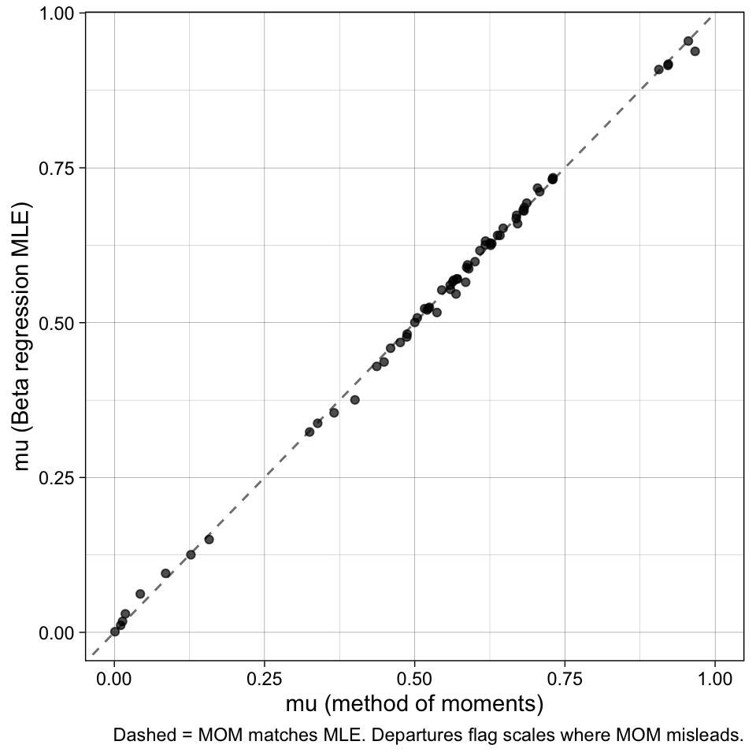

```r
ggplot(mom_vs_mle, aes(mu_mom, mu_mle)) +
  geom_abline(slope = 1, intercept = 0, linetype = "dashed", color = "grey50") +
  geom_point(alpha = 0.7) +
  #scale_x_log10() +
  #scale_y_log10() +
  labs(x = "mu (method of moments)",
       y = "mu (Beta regression MLE)",
       caption = "Dashed = MOM matches MLE. Departures flag scales where MOM misleads.") +
  theme_linedraw()
```

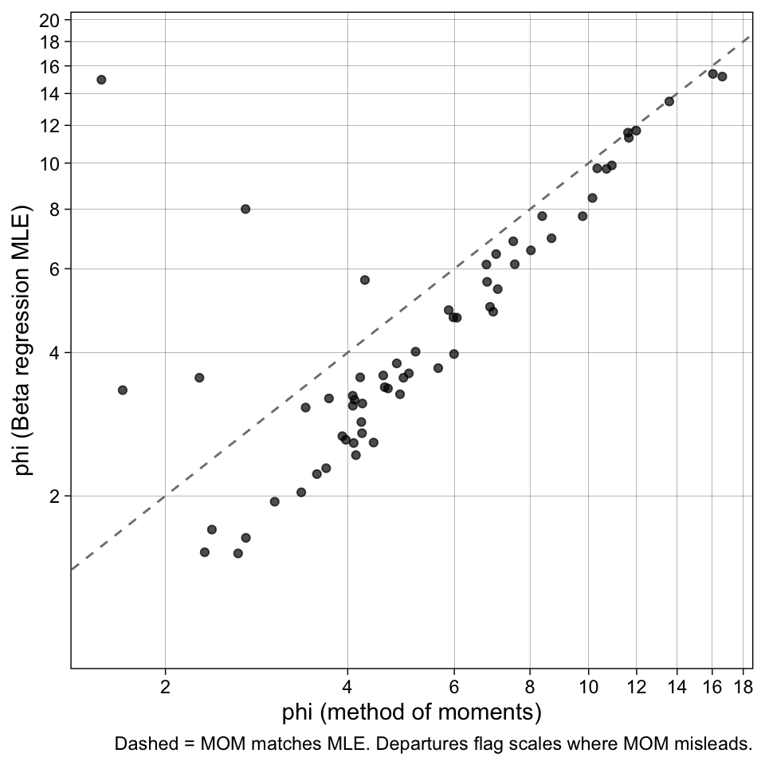

```r
ggplot(mom_vs_mle, aes(phi_mom, phi_mle)) +
  geom_abline(slope = 1, intercept = 0, linetype = "dashed", color = "grey50") +
  geom_point(alpha = 0.7) +
  scale_x_log10(breaks = breaks_pretty(n = 8)) +
  scale_y_log10(breaks = breaks_pretty(n = 8),
                limits = c(1, 18)) +
  labs(x = "phi (method of moments)",
       y = "phi (Beta regression MLE)",
       caption = "Dashed = MOM matches MLE. Departures flag scales where MOM misleads.") +
  theme_linedraw() +
  theme(panel.grid.minor = element_blank())
```

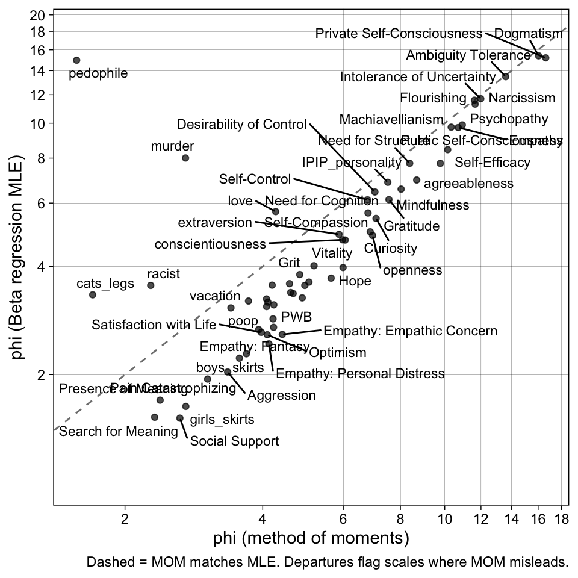

```r
ggplot(mom_vs_mle, aes(phi_mom, phi_mle, label = scale)) +
  geom_abline(slope = 1, intercept = 0, linetype = "dashed", color = "grey50") +
  geom_point(alpha = 0.7) +
  # Add the labels
  geom_text_repel(size = 3, max.overlaps = 15) +
  scale_x_log10(breaks = breaks_pretty(n = 8)) +
  scale_y_log10(breaks = breaks_pretty(n = 8), limits = c(1, 18)) +
  labs(x = "phi (method of moments)",
       y = "phi (Beta regression MLE)",
       caption = "Dashed = MOM matches MLE. Departures flag scales where MOM misleads.") +
  theme_linedraw() +
  theme(panel.grid.minor = element_blank())
```

The bulk of the scales sit near the diagonal — most multi-item Likert sum scores (BFI factors, Empathy, Self-Compassion, Mindfulness, Grit, Hope, etc.) cluster around phi_ratio ≈ 0.6–0.9. MLE is systematically a bit smaller than MOM (median ratio ≈ 0.78), which is a known small-sample / model-misspecification bias of MOM Beta — it tends to overstate precision when the data has any non-Beta features (mild bimodality, discreteness, mild tails). Order of magnitude is right; the bound you’d compute from MOM would be in the right ballpark.

```r
mom_vs_mle |>
  filter(scale %in% c("pedophile",
                      "fish_legs",
                      "murder",
                      "cats_legs",
                      "racist",
                      "love")) |>
  select(scale, mu_mom, mu_mle, mu_diff, phi_mom, phi_mle, phi_ratio) |>
  mutate_if(is.numeric, round, digits = 3) |>
  kable(caption = "Per-scale MOM vs MLE Beta fits, sorted by |log(phi_ratio)|.") |>
  kable_classic(full_width = FALSE)
```

| scale | mu_mom | mu_mle | mu_diff | phi_mom | phi_mle | phi_ratio |
| --- | --- | --- | --- | --- | --- | --- |
| cats_legs | 0.967 | 0.938 | -0.029 | 1.700 | 3.335 | 1.962 |
| fish_legs | 0.011 | 0.011 | 0.001 | 5.056 | 27.999 | 5.538 |
| love | 0.955 | 0.955 | -0.001 | 4.270 | 5.681 | 1.330 |
| murder | 0.018 | 0.030 | 0.011 | 2.712 | 8.006 | 2.952 |
| pedophile | 0.014 | 0.018 | 0.004 | 1.568 | 14.964 | 9.543 |
| racist | 0.043 | 0.062 | 0.019 | 2.276 | 3.542 | 1.556 |

These are all the single-item attitude items piled up at one end. The mechanism is exactly what the project assumes is the boundary case: when the empirical distribution is mass at a bound + some scatter, the raw variance you feed into MOM is inflated by the clumping, MOM interprets that as low precision, and the SMD bound you’d compute from it would be far too loose — because constant-φ would let SD compress only modestly as the mean shifts, when in reality the post-SD on a piled-up scale shrinks much faster. MLE Beta does better here but neither model is right; the data isn’t Beta, it’s ZOIB-shaped.

## Per-scale density: empirical vs MOM Beta vs MLE Beta

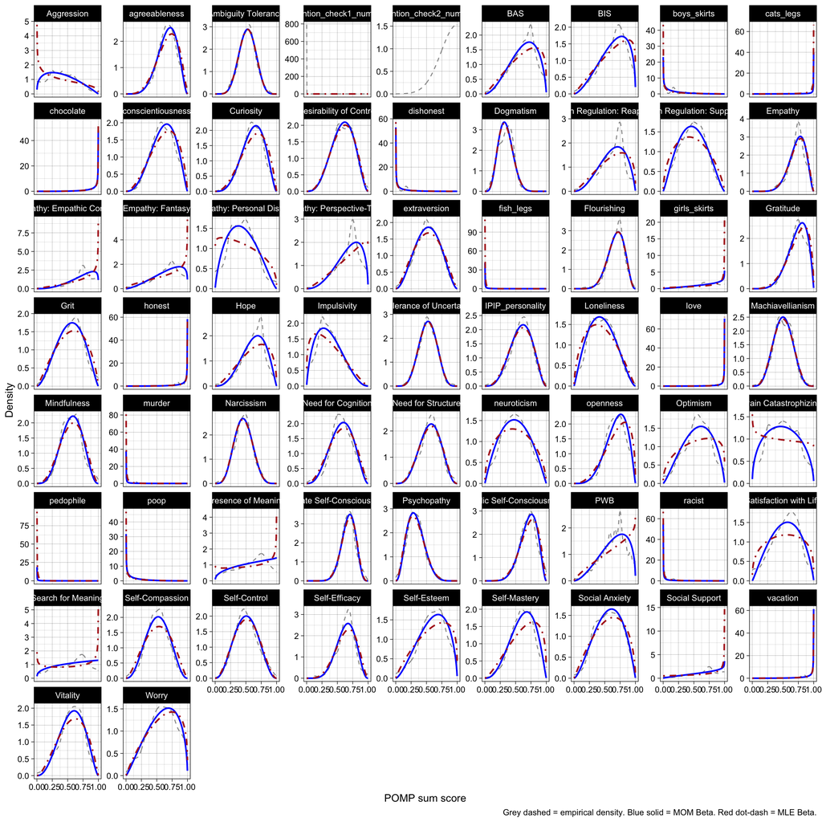

```r
mle_grid <- mom_vs_mle |>
  filter(!is.na(phi_mle)) |>
  rowwise() |>
  reframe(
    scale  = scale,
    x_val  = seq(0.001, 0.999, length.out = 200),
    y_val  = dbeta(x_val,
                   shape1 = mu_mle * phi_mle,
                   shape2 = (1 - mu_mle) * phi_mle)
  )

ggplot(dat_sumscores, aes(x = pomp_sumscore_sk_transf)) +
  geom_density(aes(y = after_stat(density)), adjust = 1,
               color = "grey60", linetype = "dashed") +
  geom_line(data = grid,     aes(x = x_val, y = y_val),
            color = "blue",      size = 0.8) +
  geom_line(data = mle_grid, aes(x = x_val, y = y_val),
            color = "firebrick", size = 0.8, linetype = "dotdash") +
  facet_wrap(~ scale, scales = "free_y") +
  coord_cartesian(xlim = c(0, 1)) +
  labs(x = "POMP sum score", y = "Density",
       caption = "Grey dashed = empirical density. Blue solid = MOM Beta. Red dot-dash = MLE Beta.") +
  theme_linedraw()
```

# Per-scale SMD bounds (Beta-implied vs naive)

For each scale, compute the SMD ceilings at the upper and lower scale endpoints under the naive linear bound (observed SD as denominator) and the Beta-implied between-groups bound (pooled SD with Beta-predicted post SD). The pooled bound asymptotes to sqrt(2) x the naive bound at the endpoints — it is mathematically *looser* than naive there, not tighter, because it honestly accounts for the fact that observed SD will compress as the mean approaches a bound. The interesting quantities are therefore the *absolute* magnitudes of the per-scale ceilings, not their ratio.

```r
safe_smd_bounds <- function(M, SD) {
  if (!is.finite(SD) || SD <= 0 || !is.finite(M) || M <= 0 || M >= 1) {
    return(list(naive  = c(up = NA_real_, down = NA_real_),
                pooled = c(up = NA_real_, down = NA_real_)))
  }
  smd_bounds(M = M, SD = SD, scale_min = 0, scale_max = 1)
}

bounds_per_scale <- beta_params |>
  rowwise() |>
  mutate(
    bounds      = list(safe_smd_bounds(m_pomp, sd_pomp)),
    naive_up    = bounds$naive[["up"]],
    naive_down  = bounds$naive[["down"]],
    pooled_up   = bounds$pooled[["up"]],
    pooled_down = bounds$pooled[["down"]]
  ) |>
  ungroup() |>
  select(scale, m_pomp, sd_pomp,
         naive_up,   pooled_up,
         naive_down, pooled_down)

bounds_per_scale |>
  mutate_if(is.numeric, round, digits = 3) |>
  kable(caption = "Per-scale SMD ceilings at the upper and lower endpoints.") |>
  kable_classic(full_width = FALSE)
```

Per-scale SMD ceilings at the upper and lower endpoints.

| scale | m_pomp | sd_pomp | naive_up | pooled_up | naive_down | pooled_down |
| --- | --- | --- | --- | --- | --- | --- |
| Aggression | 0.401 | 0.235 | 2.553 | 3.603 | -1.705 | -2.406 |
| Ambiguity Tolerance | 0.524 | 0.131 | 3.638 | 5.134 | -4.010 | -5.660 |
| BAS | 0.626 | 0.204 | 1.831 | 2.584 | -3.060 | -4.320 |
| BIS | 0.642 | 0.212 | 1.688 | 2.381 | -3.025 | -4.270 |
| Curiosity | 0.617 | 0.171 | 2.237 | 3.156 | -3.610 | -5.096 |
| Desirability of Control | 0.587 | 0.174 | 2.380 | 3.358 | -3.376 | -4.765 |
| Dogmatism | 0.338 | 0.115 | 5.771 | 8.146 | -2.953 | -4.165 |
| Emotion Regulation: Reappraisal | 0.627 | 0.197 | 1.899 | 2.679 | -3.185 | -4.496 |
| Emotion Regulation: Suppression | 0.476 | 0.210 | 2.497 | 3.524 | -2.268 | -3.200 |
| Empathy | 0.730 | 0.130 | 2.081 | 2.933 | -5.624 | -7.938 |
| Empathy: Empathic Concern | 0.729 | 0.191 | 1.419 | 2.000 | -3.816 | -5.386 |
| Empathy: Fantasy | 0.669 | 0.217 | 1.523 | 2.148 | -3.077 | -4.343 |
| Empathy: Personal Distress | 0.437 | 0.219 | 2.571 | 3.629 | -1.994 | -2.814 |
| Empathy: Perspective-Taking | 0.682 | 0.192 | 1.654 | 2.333 | -3.555 | -5.018 |
| Flourishing | 0.682 | 0.131 | 2.426 | 3.422 | -5.198 | -7.338 |
| Gratitude | 0.730 | 0.152 | 1.778 | 2.507 | -4.809 | -6.788 |
| Grit | 0.545 | 0.200 | 2.271 | 3.205 | -2.720 | -3.840 |
| Hope | 0.628 | 0.183 | 2.034 | 2.870 | -3.438 | -4.853 |
| IPIP_personality | 0.590 | 0.169 | 2.432 | 3.432 | -3.498 | -4.937 |
| Impulsivity | 0.366 | 0.198 | 3.210 | 4.532 | -1.852 | -2.612 |
| Intolerance of Uncertainty | 0.523 | 0.139 | 3.443 | 4.859 | -3.772 | -5.323 |
| Loneliness | 0.449 | 0.206 | 2.673 | 3.773 | -2.178 | -3.073 |
| Machiavellianism | 0.500 | 0.149 | 3.365 | 4.750 | -3.367 | -4.752 |
| Mindfulness | 0.565 | 0.165 | 2.638 | 3.723 | -3.422 | -4.830 |
| Narcissism | 0.460 | 0.140 | 3.855 | 5.441 | -3.282 | -4.632 |
| Need for Cognition | 0.570 | 0.177 | 2.425 | 3.422 | -3.215 | -4.539 |
| Need for Structure | 0.559 | 0.162 | 2.721 | 3.839 | -3.448 | -4.867 |
| Optimism | 0.560 | 0.220 | 2.002 | 2.825 | -2.543 | -3.590 |
| PWB | 0.647 | 0.209 | 1.688 | 2.381 | -3.096 | -4.370 |
| Pain Catastrophizing | 0.487 | 0.249 | 2.062 | 2.910 | -1.955 | -2.759 |
| Presence of Meaning | 0.585 | 0.268 | 1.551 | 2.188 | -2.184 | -3.083 |
| Private Self-Consciousness | 0.680 | 0.111 | 2.877 | 4.057 | -6.127 | -8.648 |
| Psychopathy | 0.325 | 0.136 | 4.975 | 7.022 | -2.397 | -3.380 |
| Public Self-Consciousness | 0.708 | 0.136 | 2.144 | 3.023 | -5.199 | -7.339 |
| Satisfaction with Life | 0.537 | 0.224 | 2.071 | 2.922 | -2.401 | -3.389 |
| Search for Meaning | 0.569 | 0.272 | 1.587 | 2.240 | -2.093 | -2.955 |
| Self-Compassion | 0.516 | 0.178 | 2.715 | 3.832 | -2.900 | -4.093 |
| Self-Control | 0.504 | 0.179 | 2.766 | 3.904 | -2.813 | -3.970 |
| Self-Efficacy | 0.638 | 0.146 | 2.473 | 3.489 | -4.357 | -6.150 |
| Self-Esteem | 0.600 | 0.214 | 1.866 | 2.633 | -2.803 | -3.956 |
| Self-Mastery | 0.618 | 0.189 | 2.027 | 2.860 | -3.277 | -4.626 |
| Social Anxiety | 0.563 | 0.210 | 2.079 | 2.934 | -2.683 | -3.787 |
| Social Support | 0.671 | 0.246 | 1.335 | 1.882 | -2.725 | -3.846 |
| Vitality | 0.571 | 0.186 | 2.302 | 3.249 | -3.066 | -4.328 |
| Worry | 0.588 | 0.226 | 1.820 | 2.568 | -2.596 | -3.665 |
| agreeableness | 0.670 | 0.151 | 2.186 | 3.083 | -4.430 | -6.253 |
| attention_check1_numeric | 0.001 | 0.000 | NA | NA | NA | NA |
| attention_check2_numeric | 0.999 | 0.000 | NA | NA | NA | NA |
| boys_skirts | 0.158 | 0.171 | 4.932 | 6.957 | -0.924 | -1.300 |
| cats_legs | 0.967 | 0.109 | 0.305 | 0.422 | -8.848 | -12.411 |
| chocolate | 0.906 | 0.128 | 0.733 | 1.028 | -7.091 | -9.993 |
| conscientiousness | 0.609 | 0.185 | 2.119 | 2.990 | -3.294 | -4.649 |
| dishonest | 0.085 | 0.122 | 7.473 | 10.529 | -0.698 | -0.978 |
| extraversion | 0.521 | 0.191 | 2.516 | 3.551 | -2.732 | -3.856 |
| fish_legs | 0.011 | 0.042 | 23.836 | 32.913 | -0.254 | -0.334 |
| girls_skirts | 0.704 | 0.237 | 1.249 | 1.761 | -2.976 | -4.201 |
| honest | 0.922 | 0.119 | 0.655 | 0.917 | -7.753 | -10.920 |
| love | 0.955 | 0.090 | 0.496 | 0.689 | -10.631 | -14.939 |
| murder | 0.018 | 0.070 | 14.085 | 19.639 | -0.264 | -0.358 |
| neuroticism | 0.487 | 0.222 | 2.311 | 3.262 | -2.197 | -3.101 |
| openness | 0.686 | 0.164 | 1.907 | 2.689 | -4.173 | -5.890 |
| pedophile | 0.014 | 0.072 | 13.644 | 18.936 | -0.188 | -0.252 |
| poop | 0.127 | 0.150 | 5.804 | 8.185 | -0.848 | -1.191 |
| racist | 0.043 | 0.112 | 8.518 | 11.968 | -0.385 | -0.534 |
| vacation | 0.921 | 0.128 | 0.613 | 0.859 | -7.190 | -10.128 |

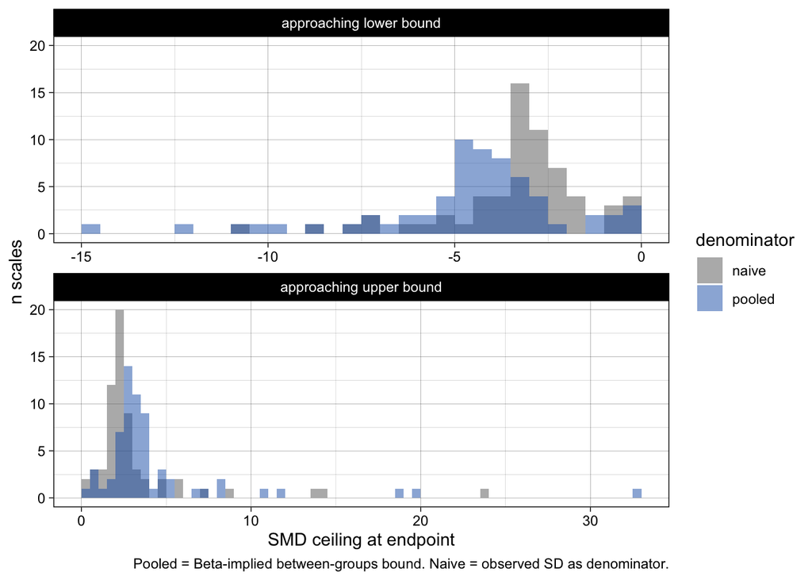

```r
bounds_long <- bounds_per_scale |>
  pivot_longer(cols = c(naive_up, pooled_up, naive_down, pooled_down),
               names_to = "bound_type",
               values_to = "smd") |>
  separate(bound_type, into = c("convention", "direction"), sep = "_") |>
  mutate(direction = recode(direction,
                            up   = "approaching upper bound",
                            down = "approaching lower bound"))

ggplot(bounds_long, aes(smd, fill = convention)) +
  geom_histogram(position = "identity", alpha = 0.5,
                 boundary = 0, binwidth = 0.5) +
  facet_wrap(~ direction, ncol = 1, scales = "free_x") +
  scale_fill_manual(values = c(naive = "grey40", pooled = "#1a5fb4")) +
  labs(x = "SMD ceiling at endpoint",
       y = "n scales",
       fill = "denominator",
       caption = "Pooled = Beta-implied between-groups bound. Naive = observed SD as denominator.") +
  theme_linedraw()
```

# POMP SD & ROMP SD

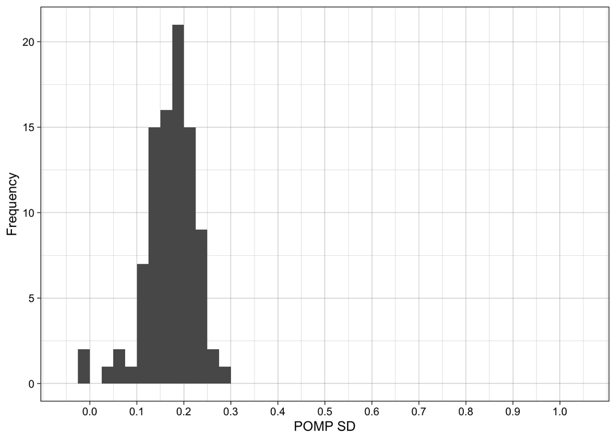

```r
# plot
ggplot(res, aes(pomp_sd)) +
  geom_histogram(boundary = 0, binwidth = .025) +
  scale_x_continuous(name = "POMP SD", limits = c(-.05, 1.05), breaks = seq(0, 1, by = .1)) +
  scale_y_continuous(name = "Frequency", breaks = seq(0, 100, by = 5)) +
  theme_linedraw()
```

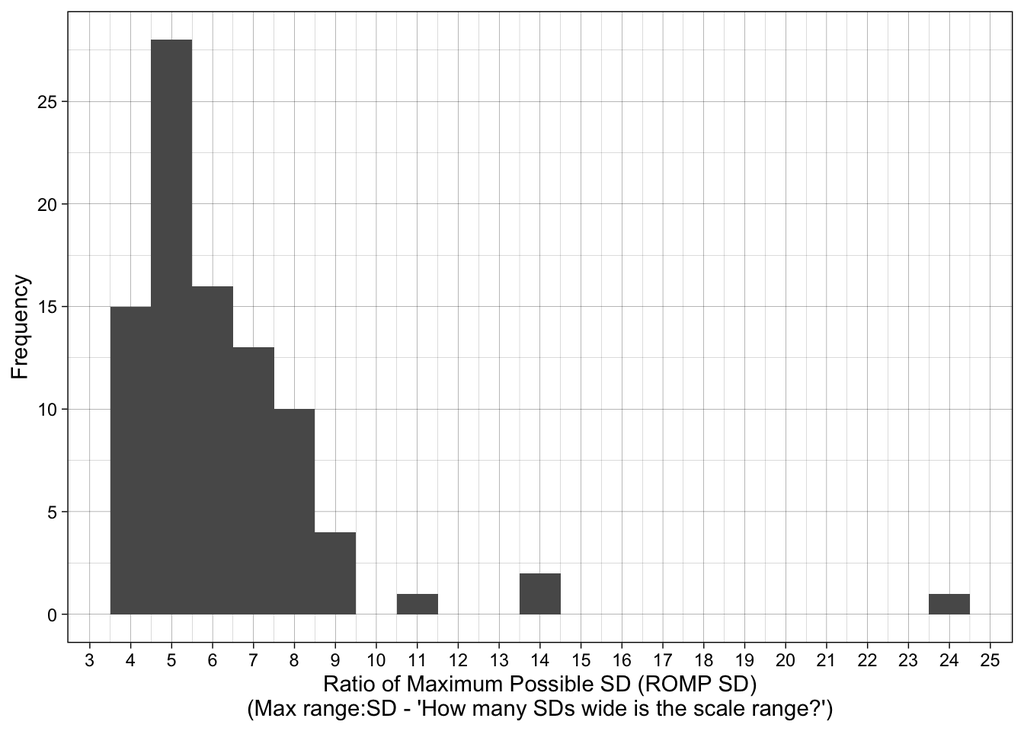

```r
# # different implementation of ROMP but same resulting value
# ggplot(res, aes(1/(sd / max_range))) +
#   geom_histogram(boundary = 0.5, binwidth = 1) +
#   scale_x_continuous(name = "ROMP SD", breaks = 0:10) +
#   scale_y_continuous(name = "Frequency", breaks = seq(0, 100, by = 5)) +
#   theme_linedraw()

# plot
ggplot(res, aes(romp_sd)) +
  geom_histogram(boundary = 0.5, binwidth = 1) +
  scale_x_continuous(name = "Ratio of Maximum Possible SD (ROMP SD)\n(Max range:SD - 'How many SDs wide is the scale range?')", breaks = 0:25) +
  scale_y_continuous(name = "Frequency", breaks = seq(0, 100, by = 5)) +
  theme_linedraw()
```

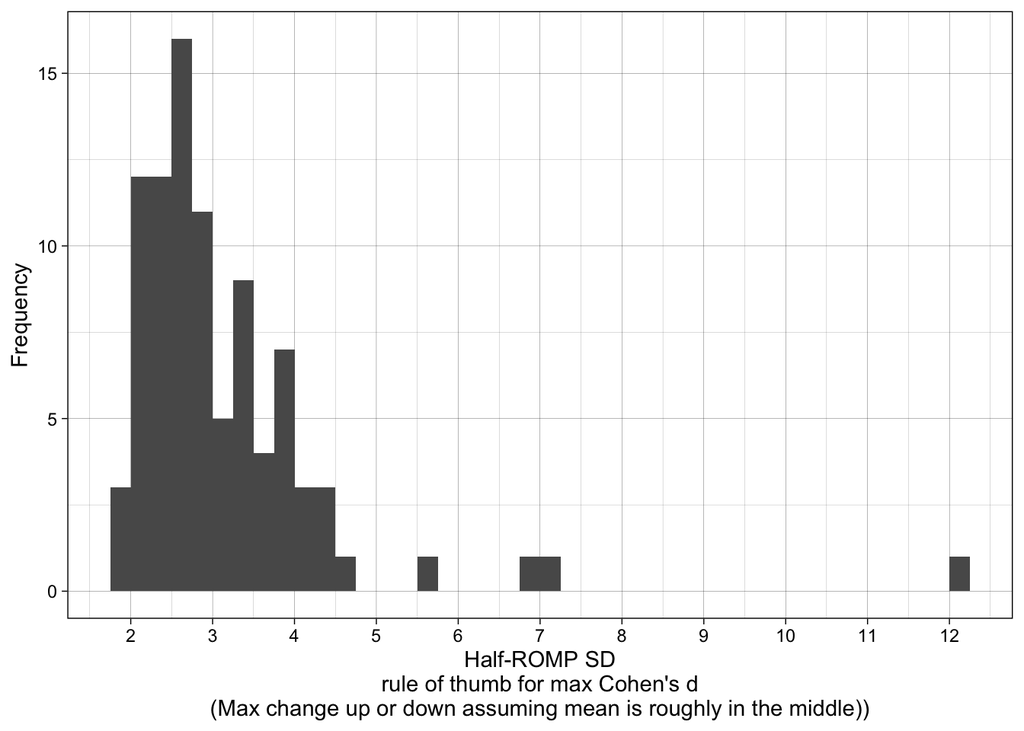

```r
ggplot(res, aes(romp_sd/2)) +
  geom_histogram(boundary = 0.5, binwidth = .25) +
  scale_x_continuous(name = "Half-ROMP SD\nrule of thumb for max Cohen's d\n(Max change up or down assuming mean is roughly in the middle))", breaks = seq(0, 20, by = 1)) +
  scale_y_continuous(name = "Frequency", breaks = seq(0, 100, by = 5)) +
  theme_linedraw()
```